# Analyzing Individual BGG Users

Phil Henrickson

2022-01-03

# **Perchy’s** BoardGameGeek Collection

This notebook contains a set of analyses for the selected user’s boardgamegeek collection. The bulk of the analysis is focused on building a user-specific predictive model to predict the games that Perchy is likely to own. This enables to ask questions like, based on the games the user currently owns, what games are a good fit for their collection? What upcoming games are they likely to purchase?

This analysis is based on data from BoardGameGeek that was last updated on **2021-12-20.**

# 1 Collection Overview

We can look at a basic description of the number of games that the user owns, has rated, has previously owned, etc.

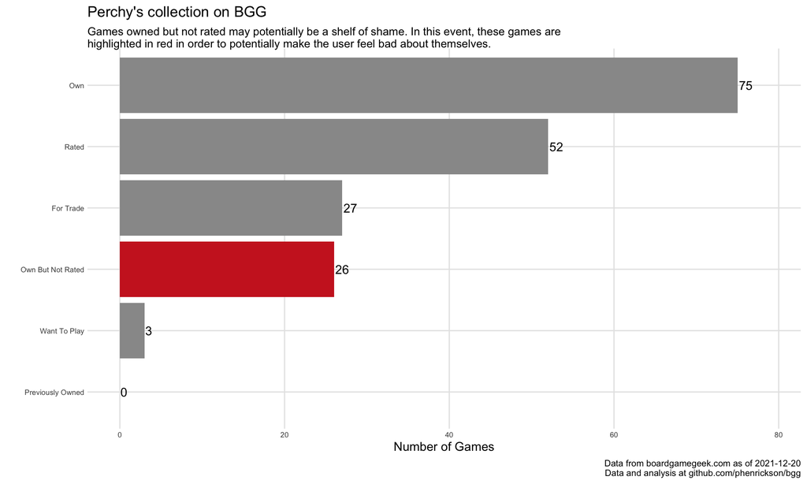

What years has the user owned/rated games from? While we can’t see when a user added or removed a game from their collection, we can look at their collection by the years in which their games were published.

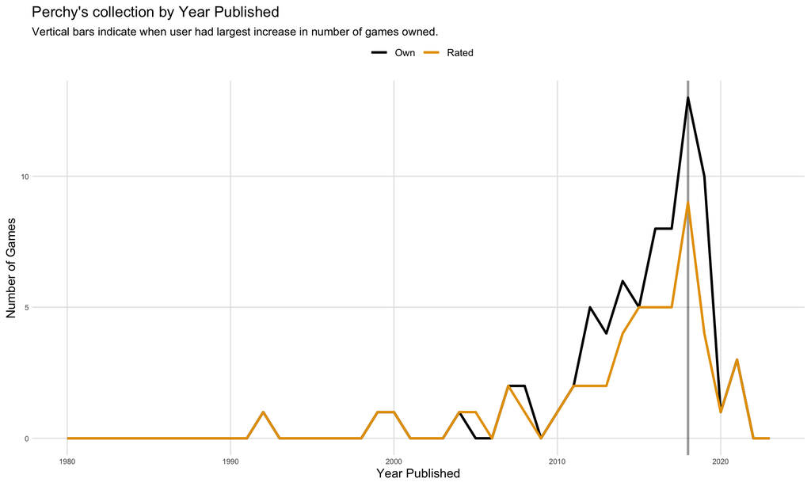

## 1.1 What types of games does Perchy own?

We can look at the most frequent types of categories, mechanics, designers, and artists that appear in a user’s collection.

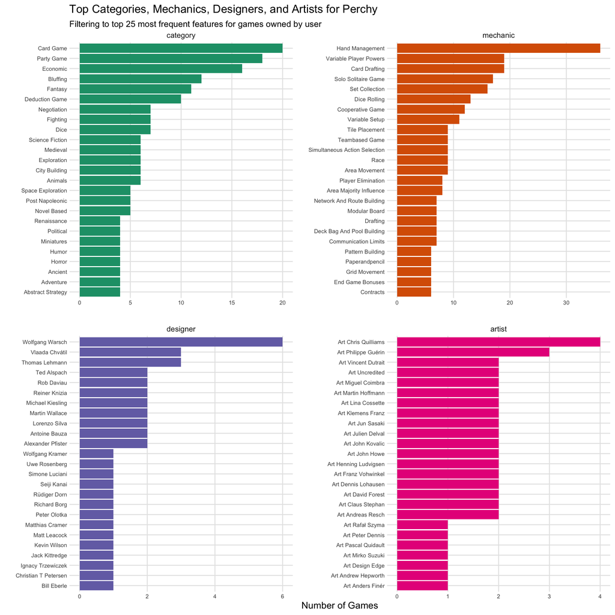

# 2 Modeling **Perchy’s** Collection

| username | dataset | period | games_owned | games_rated | games_played |
| --- | --- | --- | --- | --- | --- |
| Perchy | training | published before 2020 | 70 | 47 | 73 |
| Perchy | test | published 2020 or later | 4 | 4 | 4 |

There are two main (binary) outcomes we will be modeling for the user.

The first, **own** refers to whether the user currently lists a game as owned in their collection. The second, **played** refers to whether the user currently owns, has rated, or previously owned a game. This means the latter will generally have a larger list of games, but may still be a useful category to examine for people who play lots of games without necessarily owning them.

We will train predictive models to learn the probability that the user will own or play individual games based on their features.

## 2.1 Coefficients for Perchy

We can examine coefficients from the trained modes, which are penalized logistic regressions fit to our two main outcomes. Positive values indicate that a feature increases a user’s probabilility of owning/rating a game, while negative values indicate a feature decreases the probability.

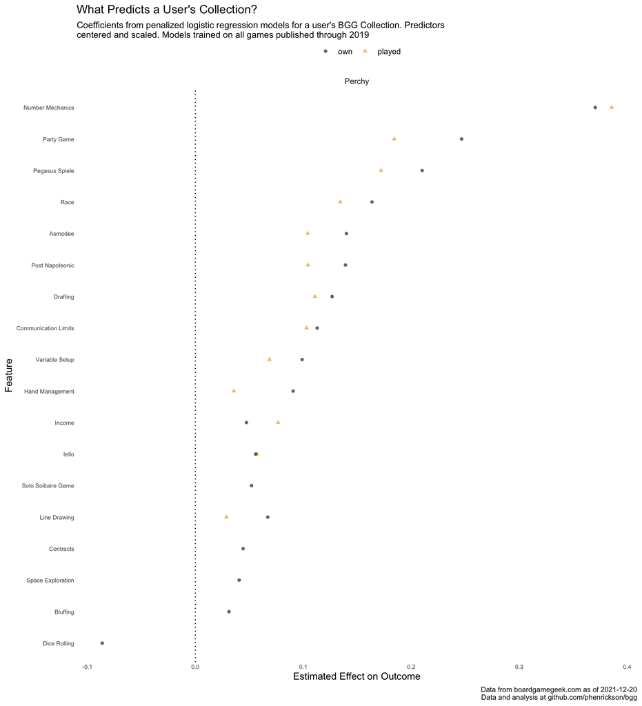

## 2.2 Visualizing Predictors for Perchy’s Collection

Why did the model identify these features? We can make density plots of the important features for predicting whether the user owned a game. Blue indicates the density for games owned by the user, while grey indicates the density for games not owned by the user.

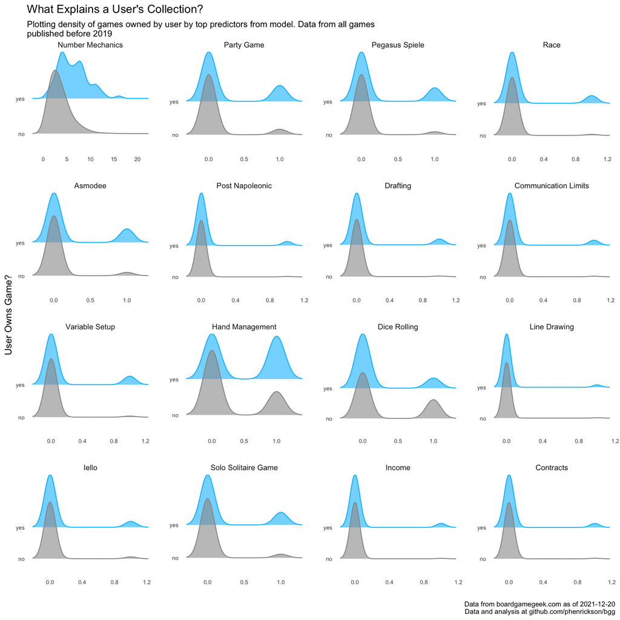

Binary predictors can be difficult to see with this visualization, so we can also directly examine the percentage of games in a user’s collection with a predictor vs the percentage of all games with that predictor.

| username | Feature | % of Games with Feature In_Collection | % of Games with Feature All_Games | Ratio |
| --- | --- | --- | --- | --- |
| Perchy | Income | 7.1% | 0.7% | 10.5 |
| Perchy | Drafting | 10.0% | 1.0% | 10.2 |
| Perchy | Communication Limits | 8.6% | 0.9% | 9.2 |
| Perchy | Post Napoleonic | 7.1% | 0.9% | 8.4 |
| Perchy | Variable Setup | 14.3% | 1.8% | 8.0 |
| Perchy | Race | 12.9% | 1.8% | 7.2 |
| Perchy | Contracts | 7.1% | 1.0% | 7.2 |
| Perchy | Line Drawing | 4.3% | 0.7% | 6.1 |
| Perchy | Pegasus Spiele | 21.4% | 4.6% | 4.6 |
| Perchy | Space Exploration | 7.1% | 1.6% | 4.3 |
| Perchy | Asmodee | 21.4% | 5.3% | 4.1 |
| Perchy | Alderac Entertainment Group | 5.7% | 1.5% | 3.7 |
| Perchy | Solo Solitaire Game | 20.0% | 5.8% | 3.4 |
| Perchy | Iello | 10.0% | 3.1% | 3.2 |
| Perchy | Party Game | 24.3% | 8.3% | 2.9 |
| Perchy | Renaissance | 5.7% | 2.0% | 2.9 |
| Perchy | Negotiation | 10.0% | 3.6% | 2.8 |
| Perchy | Bluffing | 17.1% | 6.7% | 2.6 |
| Perchy | Word Game | 4.3% | 1.8% | 2.4 |
| Perchy | Ravensburger | 7.1% | 3.2% | 2.3 |
| Perchy | Economic | 21.4% | 10.0% | 2.2 |
| Perchy | Hand Management | 48.6% | 26.6% | 1.8 |
| Perchy | Horror | 4.3% | 4.0% | 1.1 |
| Perchy | Dice Rolling | 15.7% | 29.0% | 0.5 |
| Perchy | Acting | 0.0% | 1.1% | 0.0 |

# 3 Assess Model’s Performance on Training Set

Before predicting games in upcoming years, we can examine how well the model did and what games it liked in the training set. In this case, we used resampling techniques (cross validation) to ensure that the model had not seen a game before making its predictions.

## 3.1 Separation Plot

An easy way to examine the performance of classification model is to view a separation plot. We plot the predicted probabilities from the model for every game (from resampling) from lowest to highest. We then overlay a blue line for any game that the user does own. A good classifier is one that is able to *separate* the blue (games owned by the user) from the white (games not owned by the user), with most of the blue occurring at the highest probabilities (right side of the chart).

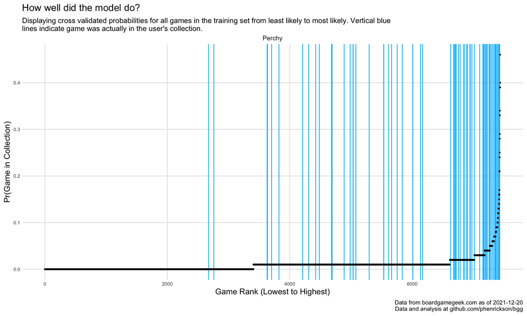

## 3.2 Top Games for **Perchy** from Training Set

We can display this information in table form, displaying the 100 games with the highest probability of ownership, adding a blue line when the user does own the game.

| username | yearpublished | game_id | name | pred_played | pred_own | actual_played | actual_own |
| --- | --- | --- | --- | --- | --- | --- | --- |
| Perchy | 2018 | 244711 | Newton | 0.34 | 0.46 | 0 | 0 |
| Perchy | 2016 | 167791 | Terraforming Mars | 0.30 | 0.40 | 0 | 0 |
| Perchy | 2014 | 156129 | Deception: Murder in Hong Kong | 0.28 | 0.39 | 0 | 0 |
| Perchy | 2018 | 205896 | Rising Sun | 0.64 | 0.39 | 0 | 0 |
| Perchy | 2007 | 29937 | König von Siam | 0.32 | 0.34 | 0 | 0 |
| Perchy | 2017 | 174430 | Gloomhaven | 0.54 | 0.33 | 0 | 0 |
| Perchy | 2013 | 144239 | Impulse | 0.22 | 0.29 | 0 | 0 |
| Perchy | 2019 | 283863 | The Magnificent | 0.34 | 0.28 | 0 | 0 |
| Perchy | 2019 | 276025 | Maracaibo | 0.13 | 0.25 | 1 | 1 |
| Perchy | 2018 | 199792 | Everdell | 0.09 | 0.24 | 0 | 0 |
| Perchy | 2016 | 155821 | Inis | 0.10 | 0.21 | 1 | 1 |
| Perchy | 2019 | 270971 | Era: Medieval Age | 0.16 | 0.21 | 0 | 0 |
| Perchy | 2018 | 246297 | Shadows: Amsterdam | 0.10 | 0.21 | 0 | 0 |
| Perchy | 2015 | 175878 | 504 | 0.10 | 0.17 | 0 | 0 |
| Perchy | 2017 | 216658 | Smash Up: What Were We Thinking? | 0.10 | 0.16 | 0 | 0 |
| Perchy | 2011 | 70919 | Takenoko | 0.08 | 0.16 | 0 | 0 |
| Perchy | 2012 | 122522 | Smash Up | 0.10 | 0.16 | 0 | 0 |
| Perchy | 2019 | 260710 | Amul | 0.08 | 0.16 | 0 | 0 |
| Perchy | 2017 | 221805 | Breaking Bad: The Board Game | 0.16 | 0.16 | 0 | 0 |
| Perchy | 2012 | 128780 | Pax Porfiriana | 0.11 | 0.15 | 0 | 0 |
| Perchy | 2015 | 170216 | Blood Rage | 0.03 | 0.14 | 0 | 0 |
| Perchy | 2016 | 191189 | Aeon's End | 0.07 | 0.14 | 0 | 0 |
| Perchy | 2017 | 228341 | Pulsar 2849 | 0.03 | 0.13 | 0 | 0 |
| Perchy | 2019 | 283294 | Yukon Airways | 0.05 | 0.13 | 0 | 0 |
| Perchy | 2015 | 180593 | The Bloody Inn | 0.14 | 0.13 | 0 | 0 |
| Perchy | 2016 | 199478 | Flamme Rouge | 0.08 | 0.13 | 0 | 0 |
| Perchy | 2007 | 28720 | Brass: Lancashire | 0.08 | 0.13 | 1 | 1 |
| Perchy | 2018 | 224517 | Brass: Birmingham | 0.05 | 0.13 | 1 | 1 |
| Perchy | 2003 | 7240 | Vanished Planet | 0.12 | 0.13 | 0 | 0 |
| Perchy | 2014 | 154203 | Imperial Settlers | 0.11 | 0.12 | 0 | 0 |

[output cut: 70 more lines]

We can also more formally assess how well the model did in resampling by looking at the area under the receiver operating characteristic. A perfect model would receive a score of 1, while a model that cannot predict the outcome will default to a score of 0.5. The extent to which something is a *good* score depends on the setting, but generally anything in the .8 to .9 range is very good while the .7 to .8 range is perfectly acceptable.

| username | outcome_type | .metric | .estimator | .estimate |
| --- | --- | --- | --- | --- |
| Perchy | own | roc_auc | binary | 0.860 |
| Perchy | played | roc_auc | binary | 0.841 |

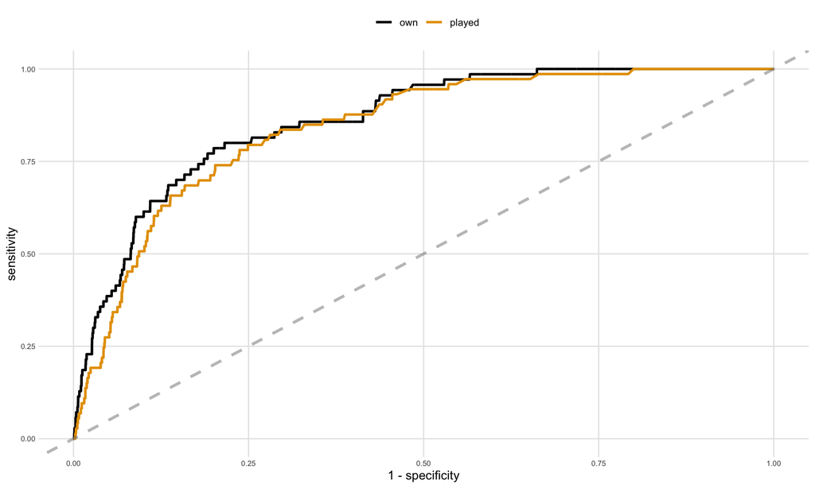

Another way to think about the model performance is to view its lift, or its ability to detect the positive outcomes over that of a null model. High lift indicates the model can much more quickly find all of the positive outcomes (in this case, games owned or played by the user), while a model with no lift is no better than random guessing.

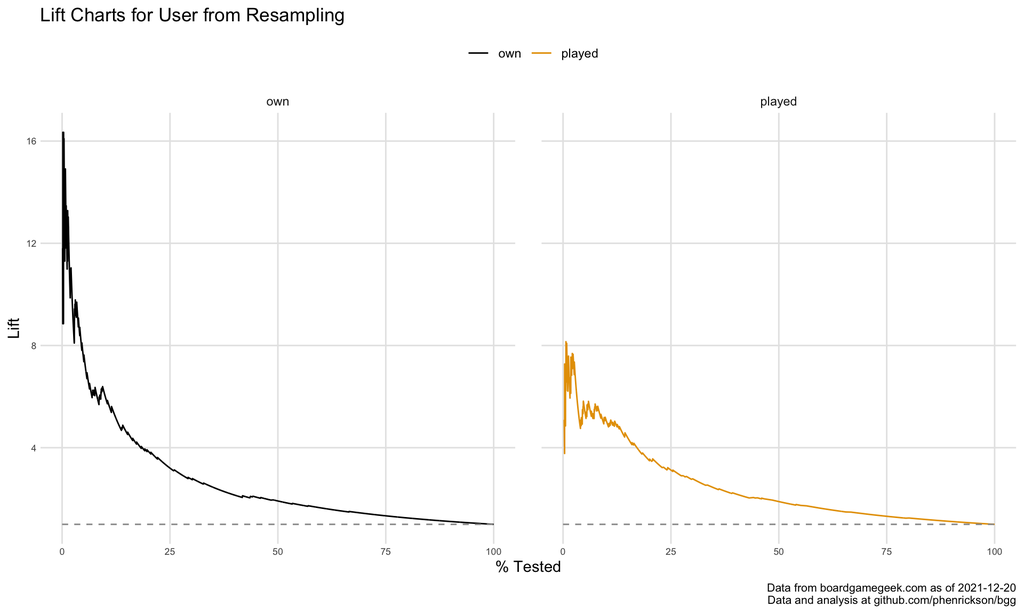

## 3.3 Most and Least Likely Games

What games does the model think Perchy is **most likely to own** that are **not** in their collection?

| username | yearpublished | game_id | name | pred_own | actual_own |
| --- | --- | --- | --- | --- | --- |
| Perchy | 2018 | 244711 | Newton | 0.46 | 0 |
| Perchy | 2016 | 167791 | Terraforming Mars | 0.40 | 0 |
| Perchy | 2014 | 156129 | Deception: Murder in Hong Kong | 0.39 | 0 |
| Perchy | 2018 | 205896 | Rising Sun | 0.39 | 0 |
| Perchy | 2007 | 29937 | König von Siam | 0.34 | 0 |

What games does the model think Perchy is **least likely to own** that **are** in their collection?

| username | yearpublished | game_id | name | pred_own | actual_own |
| --- | --- | --- | --- | --- | --- |
| Perchy | 2019 | 266083 | L.L.A.M.A. | 0.00 | 1 |
| Perchy | 2015 | 169124 | Flick 'em Up! | 0.00 | 1 |
| Perchy | 2013 | 147930 | King & Assassins | 0.01 | 1 |
| Perchy | 2015 | 173346 | 7 Wonders Duel | 0.01 | 1 |
| Perchy | 2000 | 2655 | Hive | 0.01 | 1 |

## 3.4 Top Games by Year

Top 25 games most likely to be owned by the user in each year, highlighting in blue the games that the user has owned/played.

| rank | 2011 | 2012 | 2013 | 2014 | 2015 | 2016 | 2017 | 2018 | 2019 |
| --- | --- | --- | --- | --- | --- | --- | --- | --- | --- |
| 1 | Takenoko | Smash Up | Impulse | Deception: Murder in Hong Kong | 504 | Terraforming Mars | Gloomhaven | Newton | The Magnificent |
| 2 | Pictomania | Pax Porfiriana | Ladies & Gentlemen | Imperial Settlers | Blood Rage | Inis | Smash Up: What Were We Thinking? | Rising Sun | Maracaibo |
| 3 | Letters from Whitechapel | Keyflower | A Study in Emerald | La Granja | The Bloody Inn | Aeon's End | Breaking Bad: The Board Game | Everdell | Era: Medieval Age |
| 4 | Dungeon Fighter | The Manhattan Project | Room 25 | Spyfall | The Pursuit of Happiness | Flamme Rouge | Pulsar 2849 | Shadows: Amsterdam | Amul |
| 5 | Mage Knight Board Game | Seasons | Legacy: The Testament of Duke de Crecy | Ultimate Werewolf | The King Is Dead | Captain Sonar | Gaia Project | Brass: Birmingham | Yukon Airways |
| 6 | Panic Station | Robinson Crusoe: Adventures on the Cursed Island | Lewis & Clark: The Expedition | Roll for the Galaxy | Grand Austria Hotel | Junk Art | Paper Tales | Root | Clank!: Legacy – Acquisitions Incorporated |
| 7 | Space Empires: 4X | Space Cadets | BANG! The Dice Game | Nations: The Dice Game | The Voyages of Marco Polo | Beyond Baker Street | Fog of Love | Underwater Cities | Chai |
| 8 | Village | Rumble in the Dungeon | Bomb Squad | Camel Up | Codenames | Agricola (Revised Edition) | Magic Maze | Decrypto | Tainted Grail: The Fall of Avalon |
| 9 | Rumble in the House | Terra Mystica | Rococo | HINT | Mysterium | When I Dream | Twilight Imperium: Fourth Edition | Century: Eastern Wonders | Aquatica |
| 10 | Martian Dice | Wiz-War (Eighth Edition) | Colonialism | Istanbul | Mombasa | Smash Up: Cease and Desist | Summit: The Board Game | The World of SMOG: Rise of Moloch | Nova Luna |
| 11 | Discworld: Ankh-Morpork | Il Vecchio | Theseus: The Dark Orbit | Patchwork | Trickerion: Legends of Illusion | Codenames: Pictures | Sagrada | Cosmic Run: Regeneration | Century: A New World |
| 12 | Pastiche | Clash of Cultures | Salmon Run | Castles of Mad King Ludwig | Raptor | Roll Player | Clans of Caledonia | Muse: Awakenings | Cartographers |
| 13 | Eminent Domain | Freedom: The Underground Railroad | Patchistory | Sons of Anarchy: Men of Mayhem | Salem 1692 | 13 Days: The Cuban Missile Crisis | Codenames: Disney – Family Edition | Cahoots | Tuki |
| 14 | Tragedy Looper | The Big Bang Theory: The Party Game | Concept | Five Tribes | FUSE | Yokohama | This War of Mine: The Board Game | Dead Man's Doubloons | Tiny Towns |
| 15 | Telestrations: 12 Player Party Pack | Yedo | Race! Formula 90 | Sheep & Thief | ...and then, we held hands. | The Oracle of Delphi | Whitehall Mystery | Cosmic Encounter: 42nd Anniversary Edition | One Key |
| 16 | Sekigahara: The Unification of Japan | Rent a Hero | Euphoria: Build a Better Dystopia | Pictopia: Disney Edition | Smash Up: Pretty Pretty Smash Up | Codenames: Deep Undercover | Photosynthesis | Dice Hospital | Pharaon |
| 17 | Drako: Dragon & Dwarves | Lords of Waterdeep | Forbidden Desert | Spurs: A Tale in the Old West | Sylvion | The Networks | Rescue Polar Bears: Data & Temperature | Blackout: Hong Kong | It's a Wonderful World |
| 18 | Streams | Kemet | Smash Up: Awesome Level 9000 | Legendary Encounters: An Alien Deck Building Game | My Village | The Oregon Trail Card Game | Azul | The Grizzled: Armistice Edition | Pax Pamir: Second Edition |
| 19 | Santiago de Cuba | Divided Republic | The Ravens of Thri Sahashri | Sheriff of Nottingham | Risk: Europe | Great Western Trail | Harvest Dice | Duelosaur Island | Blitzkrieg!: World War Two in 20 Minutes |
| 20 | Octopus's Garden | Among the Stars | Navajo Wars | Akrotiri | Smash Up: Munchkin | Capital Lux | Spirit Island | Coimbra | The Isle of Cats |
| 21 | Kingdom Builder | One Night Werewolf | City of Remnants | Smash Up: Monster Smash | Karuba | Citadels | Outlive | Monolith Arena | Black Angel |
| 22 | Mondo | Zombicide | Coal Baron | Witness | Steampunk Rally | Black Orchestra | Sherlock Holmes Consulting Detective: Carlton House & Queen's Park | Between Two Castles of Mad King Ludwig | Obscurio |
| 23 | Ultimate Warriorz | Coup | The Red Dragon Inn 4 | Good Cop Bad Cop | Telestrations After Dark | Pandemic: Iberia | Codenames: Marvel | Lords of Hellas | Wavelength |
| 24 | The Metagame | The Resistance: Avalon | Prosperity | Telestrations: 6 Player Family Pack | Mafia de Cuba | Comanchería: The Rise and Fall of the Comanche Empire | Century: Spice Road | Blue Lagoon | Wingspan |
| 25 | Dixit: Odyssey | Archipelago | Tash-Kalar: Arena of Legends | Praetor | Aye, Dark Overlord! The Green Box | Kingdomino | LYNGK | Luxor | Nanty Narking |

## 3.5 Interactive Predictions from Resampling

Interactive table for predictions from resampling.

|  | username | yearpublished | rank | game_id | name | pred_played | pred_own | actual_played | actual_own |
| --- | --- | --- | --- | --- | --- | --- | --- | --- | --- |
| 1 | Perchy | 1900 | 378 | 2785 | Game of Goose | 0.04 | 0.03 | 0 | 0 |
| 2 | Perchy | 1900 | 450 | 1602 | The Royal Game of Ur | 0.01 | 0.02 | 0 | 0 |
| 3 | Perchy | 1900 | 473 | 7316 | Bingo | 0.02 | 0.02 | 0 | 0 |
| 4 | Perchy | 1900 | 689 | 15878 | Rummy | 0.02 | 0.02 | 0 | 0 |
| 5 | Perchy | 1900 | 713 | 2386 | Chinese Checkers | 0.03 | 0.02 | 0 | 0 |
| 6 | Perchy | 1900 | 715 | 5432 | Chutes and Ladders | 0.02 | 0.02 | 0 | 0 |
| 7 | Perchy | 1900 | 855 | 188 | Go | 0.01 | 0.01 | 0 | 0 |
| 8 | Perchy | 1900 | 894 | 171 | Chess | 0.01 | 0.01 | 0 | 0 |
| 9 | Perchy | 1900 | 1002 | 2397 | Backgammon | 0.01 | 0.01 | 0 | 0 |
| 10 | Perchy | 1900 | 1122 | 3886 | Nine Men's Morris | 0.01 | 0.01 | 0 | 0 |

[output cut: 7426 more lines]

# 4 Validating the Model on 2020

How well did a model trained on a user’s collection through 2019 perform in predicting games for the user from 2020?

| username | outcome_type | yearpublished | .metric | .estimator | .estimate |
| --- | --- | --- | --- | --- | --- |
| Perchy | own | 2020 | roc_auc | binary | 0.938 |
| Perchy | played | 2020 | roc_auc | binary | 0.926 |

Table of top 25 games from 2020, highlighting games that the user owns.

| username | yearpublished | game_id | name | pred_own | pred_played | actual_own | actual_played |
| --- | --- | --- | --- | --- | --- | --- | --- |
| Perchy | 2020 | 184267 | On Mars | 0.41 | 0.32 | 0 | 0 |
| Perchy | 2020 | 291457 | Gloomhaven: Jaws of the Lion | 0.27 | 0.22 | 0 | 0 |
| Perchy | 2020 | 300322 | Hallertau | 0.23 | 0.17 | 0 | 0 |
| Perchy | 2020 | 246900 | Eclipse: Second Dawn for the Galaxy | 0.12 | 0.16 | 0 | 0 |
| Perchy | 2020 | 292333 | Cowboys II: Cowboys & Indians Edition | 0.11 | 0.11 | 0 | 0 |
| Perchy | 2020 | 320819 | Dinner in Paris | 0.10 | 0.10 | 0 | 0 |
| Perchy | 2020 | 245224 | La Belle Époque | 0.09 | 0.05 | 0 | 0 |
| Perchy | 2020 | 245658 | Unicorn Fever | 0.09 | 0.06 | 0 | 0 |
| Perchy | 2020 | 297030 | Tekhenu: Obelisk of the Sun | 0.08 | 0.10 | 0 | 0 |
| Perchy | 2020 | 301767 | Mysterium Park | 0.08 | 0.06 | 0 | 0 |
| Perchy | 2020 | 256317 | Guild Master | 0.07 | 0.13 | 0 | 0 |
| Perchy | 2020 | 298572 | Cosmic Encounter Duel | 0.07 | 0.03 | 0 | 0 |
| Perchy | 2020 | 302465 | Obsidia | 0.07 | 0.08 | 0 | 0 |
| Perchy | 2020 | 310442 | Feierabend | 0.07 | 0.08 | 0 | 0 |
| Perchy | 2020 | 319966 | The King Is Dead: Second Edition | 0.07 | 0.06 | 0 | 0 |
| Perchy | 2020 | 282081 | The Zorro Dice Game | 0.06 | 0.05 | 0 | 0 |
| Perchy | 2020 | 299179 | Chancellorsville 1863 | 0.06 | 0.05 | 0 | 0 |
| Perchy | 2020 | 316377 | 7 Wonders (Second Edition) | 0.06 | 0.04 | 0 | 0 |
| Perchy | 2020 | 256589 | Rallyman: GT | 0.05 | 0.04 | 0 | 0 |
| Perchy | 2020 | 298018 | Memorinth | 0.05 | 0.04 | 0 | 0 |
| Perchy | 2020 | 299592 | Beez | 0.05 | 0.03 | 0 | 0 |
| Perchy | 2020 | 306735 | Under Falling Skies | 0.05 | 0.05 | 0 | 0 |
| Perchy | 2020 | 311193 | Anno 1800 | 0.05 | 0.04 | 0 | 0 |
| Perchy | 2020 | 323784 | Ghost Letters | 0.05 | 0.04 | 0 | 0 |
| Perchy | 2020 | 267009 | Rome & Roll | 0.04 | 0.03 | 0 | 0 |

# 5 Predicting Upcoming Games (2020 and On) for **Perchy**

Examine the top games for the test set.

| username | yearpublished | game_id | name | rank | own | played |
| --- | --- | --- | --- | --- | --- | --- |
| Perchy | 2020 | 184267 | On Mars | 1 | 0.41 | 0.32 |
| Perchy | 2020 | 291457 | Gloomhaven: Jaws of the Lion | 2 | 0.27 | 0.22 |
| Perchy | 2020 | 300322 | Hallertau | 3 | 0.23 | 0.17 |
| Perchy | 2020 | 246900 | Eclipse: Second Dawn for the Galaxy | 4 | 0.12 | 0.16 |
| Perchy | 2020 | 292333 | Cowboys II: Cowboys & Indians Edition | 5 | 0.11 | 0.11 |
| Perchy | 2020 | 320819 | Dinner in Paris | 6 | 0.10 | 0.10 |
| Perchy | 2020 | 245658 | Unicorn Fever | 7 | 0.09 | 0.06 |
| Perchy | 2020 | 245224 | La Belle Époque | 8 | 0.09 | 0.05 |
| Perchy | 2020 | 301767 | Mysterium Park | 9 | 0.08 | 0.06 |
| Perchy | 2020 | 297030 | Tekhenu: Obelisk of the Sun | 10 | 0.08 | 0.10 |
| Perchy | 2020 | 298572 | Cosmic Encounter Duel | 11 | 0.07 | 0.03 |
| Perchy | 2020 | 310442 | Feierabend | 12 | 0.07 | 0.08 |
| Perchy | 2020 | 256317 | Guild Master | 13 | 0.07 | 0.13 |
| Perchy | 2020 | 302465 | Obsidia | 14 | 0.07 | 0.08 |
| Perchy | 2020 | 319966 | The King Is Dead: Second Edition | 15 | 0.07 | 0.06 |
| Perchy | 2020 | 299179 | Chancellorsville 1863 | 16 | 0.06 | 0.05 |
| Perchy | 2020 | 316377 | 7 Wonders (Second Edition) | 17 | 0.06 | 0.04 |
| Perchy | 2020 | 282081 | The Zorro Dice Game | 18 | 0.06 | 0.05 |
| Perchy | 2020 | 298018 | Memorinth | 19 | 0.05 | 0.04 |
| Perchy | 2020 | 256589 | Rallyman: GT | 20 | 0.05 | 0.04 |
| Perchy | 2020 | 306735 | Under Falling Skies | 21 | 0.05 | 0.05 |
| Perchy | 2020 | 299592 | Beez | 22 | 0.05 | 0.03 |
| Perchy | 2020 | 311193 | Anno 1800 | 23 | 0.05 | 0.04 |
| Perchy | 2020 | 323784 | Ghost Letters | 24 | 0.05 | 0.04 |
| Perchy | 2020 | 317105 | Tiny Epic Galaxies BLAST OFF! | 25 | 0.04 | 0.03 |
| Perchy | 2021 | 291859 | Riftforce | 1 | 0.35 | 0.22 |
| Perchy | 2021 | 298102 | Roll Camera!: The Filmmaking Board Game | 2 | 0.17 | 0.14 |
| Perchy | 2021 | 310873 | Carnegie | 3 | 0.17 | 0.21 |
| Perchy | 2021 | 291847 | Mantis Falls | 4 | 0.12 | 0.09 |
| Perchy | 2021 | 285967 | Ankh: Gods of Egypt | 5 | 0.11 | 0.10 |
| Perchy | 2021 | 343905 | Boonlake | 6 | 0.11 | 0.13 |
| Perchy | 2021 | 326804 | Rorschach | 7 | 0.10 | 0.07 |
| Perchy | 2021 | 298069 | Cubitos | 8 | 0.09 | 0.07 |
| Perchy | 2021 | 318084 | Furnace | 9 | 0.08 | 0.06 |
| Perchy | 2021 | 319792 | Fly-A-Way | 10 | 0.07 | 0.06 |
| Perchy | 2021 | 344408 | Full Throttle! | 11 | 0.07 | 0.06 |
| Perchy | 2021 | 342942 | Ark Nova | 12 | 0.07 | 0.07 |
| Perchy | 2021 | 283387 | Rocketmen | 13 | 0.06 | 0.03 |
| Perchy | 2021 | 324242 | Sheepy Time | 14 | 0.06 | 0.04 |
| Perchy | 2021 | 252752 | Genotype: A Mendelian Genetics Game | 15 | 0.06 | 0.05 |
| Perchy | 2021 | 304324 | Dive | 16 | 0.06 | 0.05 |
| Perchy | 2021 | 295947 | Cascadia | 17 | 0.06 | 0.04 |
| Perchy | 2021 | 322014 | All-Star Draft | 18 | 0.05 | 0.04 |
| Perchy | 2021 | 299684 | Khôra: Rise of an Empire | 19 | 0.05 | 0.08 |
| Perchy | 2021 | 295785 | Euthia: Torment of Resurrection | 20 | 0.05 | 0.04 |
| Perchy | 2021 | 333553 | For the King (and Me) | 21 | 0.05 | 0.05 |
| Perchy | 2021 | 343847 | Dustbiters | 22 | 0.05 | 0.04 |
| Perchy | 2021 | 295535 | Dark Ages: Heritage of Charlemagne | 23 | 0.05 | 0.07 |
| Perchy | 2021 | 304985 | Dark Ages: Holy Roman Empire | 24 | 0.05 | 0.07 |
| Perchy | 2021 | 301018 | Dragon Parks | 25 | 0.05 | 0.04 |
| Perchy | 2022 | 331106 | The Witcher: Old World | 1 | 0.33 | 0.23 |
| Perchy | 2022 | 295770 | Frosthaven | 2 | 0.15 | 0.13 |
| Perchy | 2022 | 334065 | Verdant | 3 | 0.08 | 0.06 |
| Perchy | 2022 | 317511 | Tindaya | 4 | 0.08 | 0.07 |
| Perchy | 2022 | 299106 | Fractal: Beyond the Void | 5 | 0.06 | 0.03 |
| Perchy | 2022 | 312959 | Rallyman: DIRT | 6 | 0.05 | 0.04 |
| Perchy | 2022 | 304051 | Creature Comforts | 7 | 0.05 | 0.03 |
| Perchy | 2022 | 326945 | Castles of Mad King Ludwig: Collector's Edition | 8 | 0.04 | 0.03 |
| Perchy | 2022 | 322524 | Bardsung | 9 | 0.04 | 0.05 |
| Perchy | 2022 | 256680 | Return to Dark Tower | 10 | 0.04 | 0.03 |
| Perchy | 2022 | 322289 | Darwin's Journey | 11 | 0.03 | 0.02 |
| Perchy | 2022 | 311988 | Frostpunk: The Board Game | 12 | 0.03 | 0.02 |
| Perchy | 2022 | 319807 | Shogun no Katana | 13 | 0.03 | 0.02 |
| Perchy | 2022 | 330950 | Age of Galaxy | 14 | 0.03 | 0.03 |
| Perchy | 2022 | 338067 | 6: Siege – The Board Game | 15 | 0.03 | 0.03 |
| Perchy | 2022 | 299594 | Megapulse | 16 | 0.03 | 0.03 |
| Perchy | 2022 | 305096 | Endless Winter: Paleoamericans | 17 | 0.02 | 0.01 |
| Perchy | 2022 | 339592 | Sheep in Disguise | 18 | 0.02 | 0.01 |
| Perchy | 2022 | 305462 | The Age of Atlantis | 19 | 0.02 | 0.01 |
| Perchy | 2022 | 240980 | Blood on the Clocktower | 20 | 0.02 | 0.01 |
| Perchy | 2022 | 280726 | Legacies | 21 | 0.02 | 0.02 |
| Perchy | 2022 | 283137 | Human Punishment: The Beginning | 22 | 0.02 | 0.03 |
| Perchy | 2022 | 331401 | Dog Park | 23 | 0.02 | 0.02 |
| Perchy | 2022 | 273814 | Deliverance | 24 | 0.02 | 0.03 |
| Perchy | 2022 | 317321 | Darkest Dungeon: The Board Game | 25 | 0.02 | 0.03 |

## 5.1 Interactive Table for Upcoming Games 2020 and On

|  | username | yearpublished | game_id | name | rank | own | played |
| --- | --- | --- | --- | --- | --- | --- | --- |
| 1 | Perchy | 2020 | 184267 | On Mars | 1 | 0.41 | 0.32 |
| 2 | Perchy | 2021 | 291859 | Riftforce | 2 | 0.35 | 0.22 |
| 3 | Perchy | 2022 | 331106 | The Witcher: Old World | 3 | 0.33 | 0.23 |
| 4 | Perchy | 2020 | 291457 | Gloomhaven: Jaws of the Lion | 4 | 0.27 | 0.22 |
| 5 | Perchy | 2020 | 300322 | Hallertau | 5 | 0.23 | 0.17 |
| 6 | Perchy | 2021 | 298102 | Roll Camera!: The Filmmaking Board Game | 6 | 0.17 | 0.14 |
| 7 | Perchy | 2021 | 310873 | Carnegie | 7 | 0.17 | 0.21 |
| 8 | Perchy | 2022 | 295770 | Frosthaven | 8 | 0.15 | 0.13 |
| 9 | Perchy | 2021 | 291847 | Mantis Falls | 9 | 0.12 | 0.09 |
| 10 | Perchy | 2020 | 246900 | Eclipse: Second Dawn for the Galaxy | 10 | 0.12 | 0.16 |

[output cut: 1627 more lines]